# DATA606_Lab8_Multiple and logistic regression

Matheesha Thambeliyagodage

May 5, 2017

```r
library(ggplot2 )
library(dplyr)
library(plyr)
library(data.table)
library(knitr)

myTheme <- theme(axis.ticks=element_blank(),
                  panel.border = element_rect(color="green", fill=NA),
                  panel.background=element_rect(fill="#FBFBFB"),
                  panel.grid.major.y=element_line(color="red", size=0.5),
                  panel.grid.major.x=element_line(color="red", size=0.5),
                  plot.title=element_text(size="10"))
```

### Grading the professor

Many college courses conclude by giving students the opportunity to evaluate the course and the instructor anonymously. However, the use of these student evaluations as an indicator of course quality and teaching effectiveness is often criticized because these measures may reflect the influence of non-teaching related characteristics, such as the physical appearance of the instructor. The article titled, “Beauty in the classroom: instructors’ pulchritude and putative pedagogical productivity” (Hamermesh and Parker, 2005) found that instructors who are viewed to be better looking receive higher instructional ratings. (Daniel S. Hamermesh, Amy Parker, Beauty in the classroom: instructors pulchritude and putative pedagogical productivity, Economics of Education Review, Volume 24, Issue 4, August 2005, Pages 369-376, ISSN 0272-7757, 10.1016/j.econedurev.2004.07.013. http://www.sciencedirect.com/science/article/pii/S0272775704001165.)

In this lab we will analyze the data from this study in order to learn what goes into a positive professor evaluation.

### The data

The data were gathered from end of semester student evaluations for a large sample of professors from the University of Texas at Austin. In addition, six students rated the professors’ physical appearance. (This is aslightly modified version of the original data set that was released as part of the replication data for Data Analysis Using Regression and Multilevel/Hierarchical Models (Gelman and Hill, 2007).) The result is a data frame where each row contains a different course and columns represent variables about the courses and professors.

```r
download.file("http://www.openintro.org/stat/data/evals.RData", destfile = "evals.RData")
load("evals.RData")
#ls()
head(evals)
```

```
##   score         rank    ethnicity gender language age cls_perc_eval
## 1   4.7 tenure track     minority female  english  36      55.81395
## 2   4.1 tenure track     minority female  english  36      68.80000
## 3   3.9 tenure track     minority female  english  36      60.80000
## 4   4.8 tenure track     minority female  english  36      62.60163
## 5   4.6      tenured not minority   male  english  59      85.00000
## 6   4.3      tenured not minority   male  english  59      87.50000
##   cls_did_eval cls_students cls_level cls_profs  cls_credits bty_f1lower
## 1           24           43     upper    single multi credit           5
## 2           86          125     upper    single multi credit           5
## 3           76          125     upper    single multi credit           5
## 4           77          123     upper    single multi credit           5
## 5           17           20     upper  multiple multi credit           4
## 6           35           40     upper  multiple multi credit           4
##   bty_f1upper bty_f2upper bty_m1lower bty_m1upper bty_m2upper bty_avg
## 1           7           6           2           4           6       5
## 2           7           6           2           4           6       5
## 3           7           6           2           4           6       5
## 4           7           6           2           4           6       5
## 5           4           2           2           3           3       3
## 6           4           2           2           3           3       3
##   pic_outfit pic_color
## 1 not formal     color
## 2 not formal     color
## 3 not formal     color
## 4 not formal     color
## 5 not formal     color
## 6 not formal     color
```

```r
df<- select(evals,score,
rank,
ethnicity,
gender,
language,
age,
cls_perc_eval,
cls_did_eval,
cls_students,
cls_level,
cls_profs,
cls_credits,
bty_f1lower,
bty_f1upper,
bty_f2upper,
bty_m1lower,
bty_m1upper,
bty_m2upper,
bty_f1lower,
bty_f1upper,
bty_f2upper,
bty_m1lower,
bty_m1upper,
bty_m2upper,
bty_avg,
pic_outfit,
pic_color)
#df
```

```r
d_df = df %>% distinct(ethnicity,rank,language)
#d_df
```

### Exploring the data

| variable | description |
| --- | --- |
| `score` | average professor evaluation score: (1) very unsatisfactory - (5) excellent. |
| `rank` | rank of professor: teaching, tenure track, tenured. |
| `ethnicity` | ethnicity of professor: not minority, minority. |
| `gender` | gender of professor: female, male. |
| `language` | language of school where professor received education: english or non-english. |
| `age` | age of professor. |
| `cls_perc_eval` | percent of students in class who completed evaluation. |
| `cls_did_eval` | number of students in class who completed evaluation. |
| `cls_students` | total number of students in class. |
| `cls_level` | class level: lower, upper. |
| `cls_profs` | number of professors teaching sections in course in sample: single, multiple. |
| `cls_credits` | number of credits of class: one credit (lab, PE, etc.), multi credit. |
| `bty_f1lower` | beauty rating of professor from lower level female: (1) lowest - (10) highest. |
| `bty_f1upper` | beauty rating of professor from upper level female: (1) lowest - (10) highest. |
| `bty_f2upper` | beauty rating of professor from second upper level female: (1) lowest - (10) highest. |
| `bty_m1lower` | beauty rating of professor from lower level male: (1) lowest - (10) highest. |
| `bty_m1upper` | beauty rating of professor from upper level male: (1) lowest - (10) highest. |
| `bty_m2upper` | beauty rating of professor from second upper level male: (1) lowest - (10) highest. |
| `bty_avg` | average beauty rating of professor. |
| `pic_outfit` | outfit of professor in picture: not formal, formal. |
| `pic_color` | color of professor’s picture: color, black & white. |

**Ex1..** **Is this an observational study or an experiment? The original research question posed in the paper is whether beauty leads directly to the differences in course evaluations. Given the study design, is it possible to answer this question as it is phrased? If not, rephrase the question.**

- This is an experiment but it uses observational data in both the the treatment (beauty measure), and with the course evaluation (as the response variable). Although the reseach is designed as an experiment, all aspects are extremely subjective any doesn’t seem to be a good design for causal inference. A better research question would be whether beauty is correlated with differences in course evaluations.

**Ex 2 ..** **Describe the distribution of score. Is the distribution skewed? What does that tell you about how students rate courses? Is this what you expected to see? Why, or why not?**

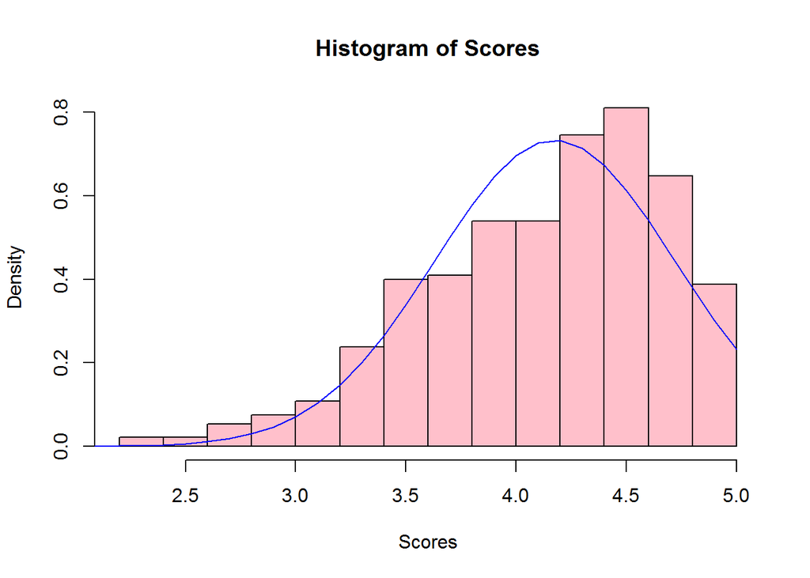

```r
hist(evals$score, main = "Histogram of Scores", xlab = "Scores", col = 'pink', probability = TRUE)
x <- seq(from = 0, to = 5, by = 0.1)
y <- dnorm(x = x, mean = mean(evals$score), sd = sd(evals$score))
lines(x = x, y = y, col = "blue")
```

- The evaluation scores are skewed to the left. Students have far more positive evaluations than negative evaluations for their teachers. This is not what Id expected. We expected a normal distribution where most teachers would be rated as average and fewer teachers will be evaluated in the extremes - excellent or unsatisfactory.

**Ex 3 ..** **Excluding score, select two other variables and describe their relationship using an appropriate visualization (scatterplot, side-by-side boxplots, or mosaic plot).**

```r
library(vcd)
```

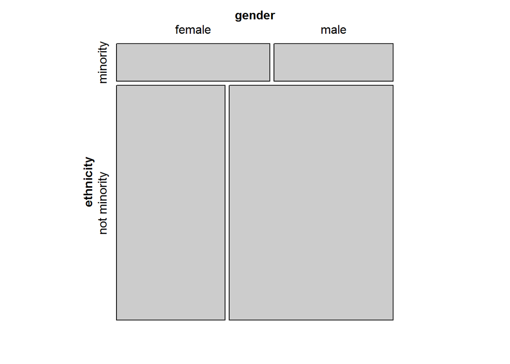

```r
## Loading required package: grid
mosaic(~ ethnicity + gender, data=evals)
```

```r
# gender
```

- Using a mosaic plot to compare professors by ethnicity and gender, it seems like it is more likely for minority professors to be women than non-minority professors.

## Simple linear regression

The fundamental phenomenon suggested by the study is that better looking teachers are evaluated more favorably. Let’s create a scatterplot to see if this appears to be the case:

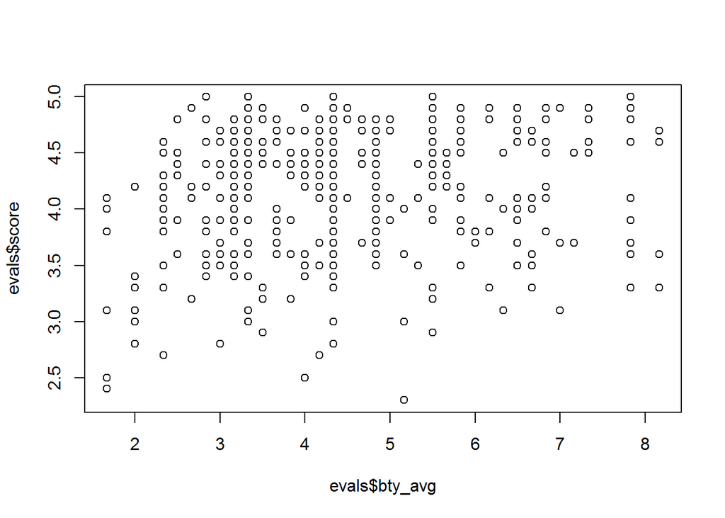

```r
plot(evals$score ~ evals$bty_avg)
```

Before we draw conclusions about the trend, compare the number of observations in the data frame with the approximate number of points on the scatterplot. Is anything awry?

**Ex 4 ..** **Replot the scatterplot, but this time use the function jitter() on the y- or the x-coordinate. (Use ?jitter to learn more.) What was misleading about the initial scatterplot?**

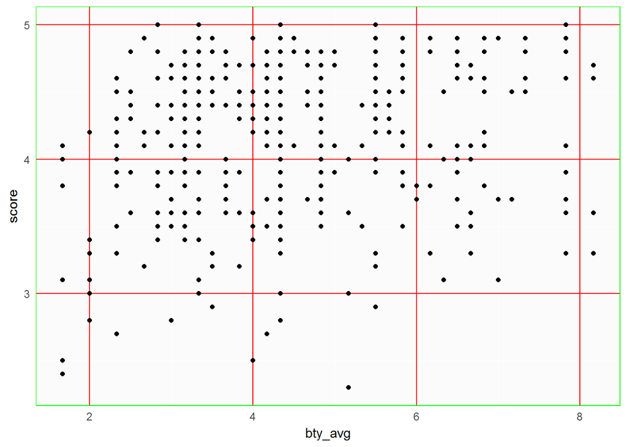

```r
ggplot(evals,aes(x=bty_avg, y=score)) + geom_point(position = "dodge") + myTheme
```

```r
nrow(evals)
```

```
## [1] 463
```

**Ex 5 ..** **Let’s see if the apparent trend in the plot is something more than natural variation. Fit a linear model called m_bty to predict average professor score by average beauty rating and add the line to your plot using abline(m_bty). Write out the equation for the linear model and interpret the slope. Is average beauty score a statistically significant predictor? Does it appear to be a practically significant predictor?**

```r
m_bty <- lm(score ~ bty_avg, data=evals)
summary(m_bty)
```

```
##
## Call:
## lm(formula = score ~ bty_avg, data = evals)
##
## Residuals:
##     Min      1Q  Median      3Q     Max
## -1.9246 -0.3690  0.1420  0.3977  0.9309
##
## Coefficients:
##             Estimate Std. Error t value Pr(>|t|)
## (Intercept)  3.88034    0.07614   50.96  < 2e-16 ***
## bty_avg      0.06664    0.01629    4.09 5.08e-05 ***
## ---
## Signif. codes:  0 '***' 0.001 '**' 0.01 '*' 0.05 '.' 0.1 ' ' 1
##
## Residual standard error: 0.5348 on 461 degrees of freedom
## Multiple R-squared:  0.03502,    Adjusted R-squared:  0.03293
## F-statistic: 16.73 on 1 and 461 DF,  p-value: 5.083e-05
```

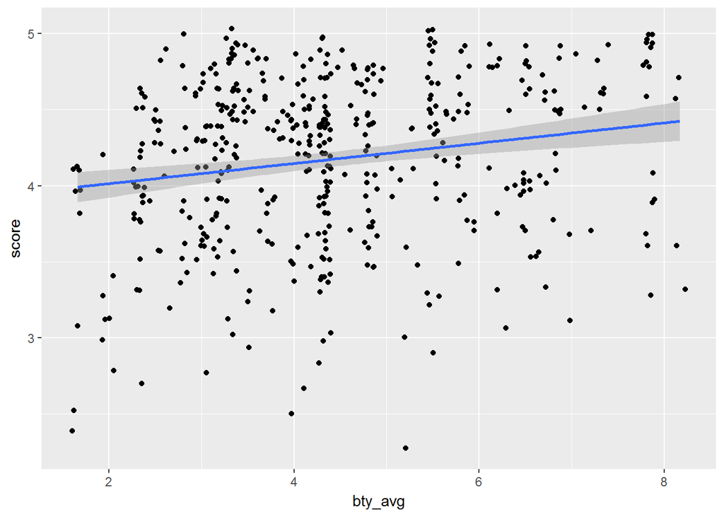

```r
ggplot(evals,aes(x=bty_avg, y=score)) + geom_point(position = "jitter") +
stat_smooth(method="lm")
```

- Yes, It appears to be somewhat predictive, bty_avg is a statistically significant predictor of evaluation score with p-value close of 0. It may not be a practically significant predictor of evaluation score though since for every 1 point increase in bty_ave, the model only predicts an increase of 0.06664 which barely changes the evaluation score.

**Ex 6 ..** **Use residual plots to evaluate whether the conditions of least squares regression are reasonable. Provide plots and comments for each one (see the Simple Regression Lab for a reminder of how to make these).**

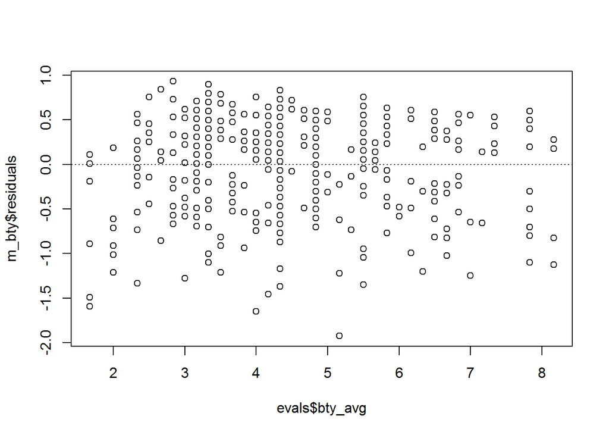

```r
plot(m_bty$residuals ~ evals$bty_avg)
abline(h = 0, lty = 3)  # adds a horizontal dashed line at y = 0
```

- Nearly normal residuals: Based on the plot above, the residuals appear to be nearly normal. Linearity: The data are clearly not having a narrow linear relationship. The points are wide in their trend.

## Multiple linear regression

- The data set contains several variables on the beauty score of the professor: individual ratings from each of the six students who were asked to score the physical appearance of the professors and the average of these six scores. Let’s take a look at the relationship between one of these scores and the average beauty score.

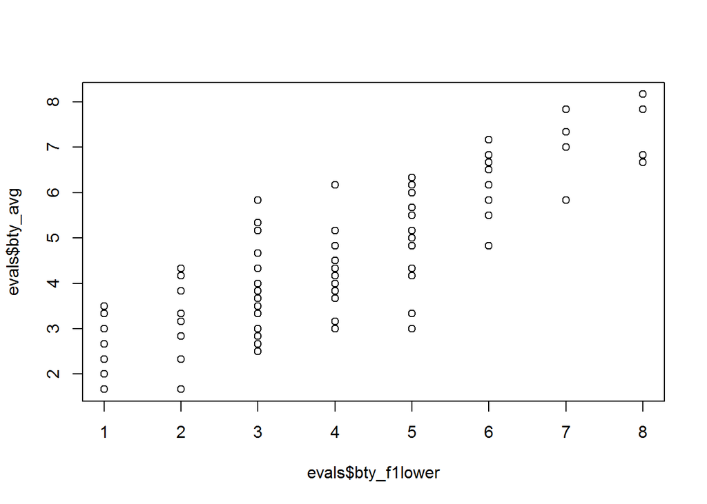

```r
plot(evals$bty_avg ~ evals$bty_f1lower)
```

```r
cor(evals$bty_avg, evals$bty_f1lower)
```

```
## [1] 0.8439112
```

- As expected the relationship is quite strong - after all, the average score is calculated using the individual scores. We can actually take a look at the relationships between all beauty variables (columns 13 through 19) using the following command:

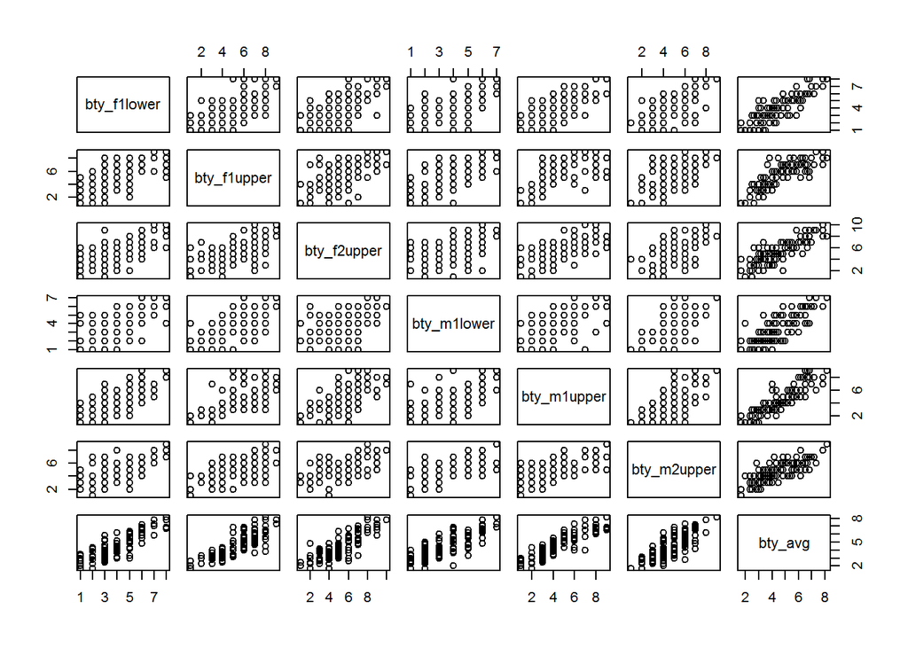

```r
plot(evals[,13:19])
```

- These variables are collinear (correlated), and adding more than one of these variables to the model would not add much value to the model. In this application and with these highly-correlated predictors, it is reasonable to use the average beauty score as the single representative of these variables.

In order to see if beauty is still a significant predictor of professor score after we’ve accounted for the gender of the professor, we can add the gender term into the model.

```r
m_bty_gen <- lm(score ~ bty_avg + gender, data = evals)
summary(m_bty_gen)
```

```
##
## Call:
## lm(formula = score ~ bty_avg + gender, data = evals)
##
## Residuals:
##     Min      1Q  Median      3Q     Max
## -1.8305 -0.3625  0.1055  0.4213  0.9314
##
## Coefficients:
##             Estimate Std. Error t value Pr(>|t|)
## (Intercept)  3.74734    0.08466  44.266  < 2e-16 ***
## bty_avg      0.07416    0.01625   4.563 6.48e-06 ***
## gendermale   0.17239    0.05022   3.433 0.000652 ***
## ---
## Signif. codes:  0 '***' 0.001 '**' 0.01 '*' 0.05 '.' 0.1 ' ' 1
##
## Residual standard error: 0.5287 on 460 degrees of freedom
## Multiple R-squared:  0.05912,    Adjusted R-squared:  0.05503
## F-statistic: 14.45 on 2 and 460 DF,  p-value: 8.177e-07
```

**Ex 7 ..** **P-values and parameter estimates should only be trusted if the conditions for the regression are reasonable. Verify that the conditions for this model are reasonable using diagnostic plots.**

```r
library(StMoSim)
```

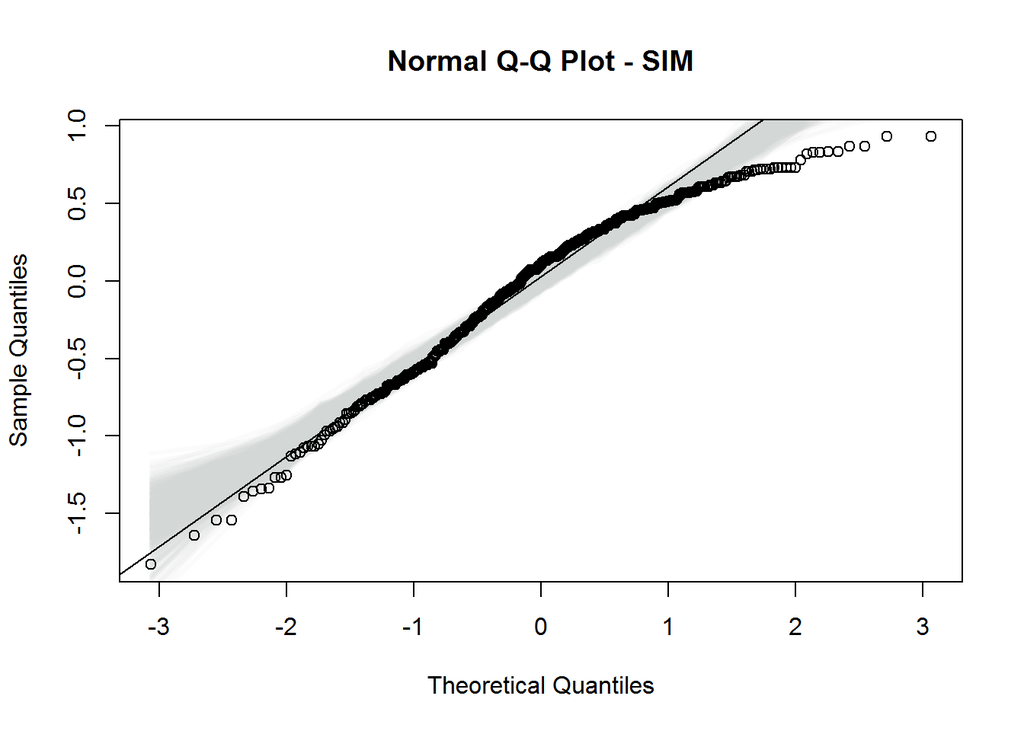

```r
qqnormSim(m_bty_gen$residuals)
```

- The residuals of the model is not normal as residual values for the the higher quantiles are less than what a normal distribution would predict

**Ex 8 ..** **Is bty_avg still a significant predictor of score? Has the addition of gender to the model changed the parameter estimate for bty_avg?**

Note that the estimate for gender is now called gendermale. You’ll see this name change whenever you introduce a categorical variable. The reason is that R recodes gender from having the values of female and male to being an indicator variable called gendermale that takes a value of 0 for females and a value of 1 for males. (Such variables are often referred to as “dummy” variables.) As a result, for females, the parameter estimate is multiplied by zero, leaving the intercept and slope form familiar from simple regression.

$$\begin{aligned}
\widehat{score} &= \hat{\beta}_0 + \hat{\beta}_1 \times bty\_avg + \hat{\beta}_2 \times (0) \\
&= \hat{\beta}_0 + \hat{\beta}_1 \times bty\_avg\end{aligned}$$

- We can plot this line and the line corresponding to males with the following custom function.

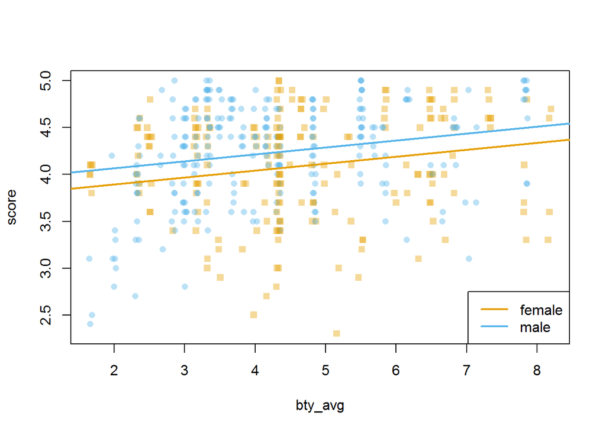

```r
multiLines(m_bty_gen)
```

**Ex 9 ..**

**What is the equation of the line corresponding to males? (Hint: For males, the parameter estimate is multiplied by 1.) For two professors who received the same beauty rating, which gender tends to have the higher course evaluation score?**

- This is just the genderemale parameter plus the intercept, since if we’re only looking at males this will always be 1. For two professors who received the same beauty rating, males would be predicted to have higher scores.

**Ex 10 ..**

**Create a new model called m_bty_rank with gender removed and rank added in. How does R appear to handle categorical variables that have more than two levels? Note that the rank variable has three levels: teaching, tenure track, tenured.**

```r
m_bty_rank <- lm(score ~ bty_avg + rank, data=evals)
summary(m_bty_rank)
```

```
##
## Call:
## lm(formula = score ~ bty_avg + rank, data = evals)
##
## Residuals:
##     Min      1Q  Median      3Q     Max
## -1.8713 -0.3642  0.1489  0.4103  0.9525
##
## Coefficients:
##                  Estimate Std. Error t value Pr(>|t|)
## (Intercept)       3.98155    0.09078  43.860  < 2e-16 ***
## bty_avg           0.06783    0.01655   4.098 4.92e-05 ***
## ranktenure track -0.16070    0.07395  -2.173   0.0303 *
## ranktenured      -0.12623    0.06266  -2.014   0.0445 *
## ---
## Signif. codes:  0 '***' 0.001 '**' 0.01 '*' 0.05 '.' 0.1 ' ' 1
##
## Residual standard error: 0.5328 on 459 degrees of freedom
## Multiple R-squared:  0.04652,    Adjusted R-squared:  0.04029
## F-statistic: 7.465 on 3 and 459 DF,  p-value: 6.88e-05
```

- If there are n levels, R adds n-1 variables. These represent n-1 categories, with the nth category represented by all the variables being 0.

## The search for the best model

We will start with a full model that predicts professor score based on rank, ethnicity, gender, language of the university where they got their degree, age, proportion of students that filled out evaluations, class size, course level, number of professors, number of credits, average beauty rating, outfit, and picture color.

**Ex 11 ..**

**Which variable would you expect to have the highest p-value in this model? Why? Hint: Think about which variable would you expect to not have any association with the professor score. This is actually a toss up for me. . . All of these variables could conceptually affect student rankings. If I had to guess, I would think that ethnicity might play the lowest role.**

Let’s run the model.

- I would hypothesize that language, language of the university where they got their degree, would have the highest p-value.

```r
m_full <- lm(score ~ rank + ethnicity + gender + language + age + cls_perc_eval
             + cls_students + cls_level + cls_profs + cls_credits + bty_avg
             + pic_outfit + pic_color, data = evals)
summary(m_full)
```

```
##
## Call:
## lm(formula = score ~ rank + ethnicity + gender + language + age +
##     cls_perc_eval + cls_students + cls_level + cls_profs + cls_credits +
##     bty_avg + pic_outfit + pic_color, data = evals)
##
## Residuals:
##      Min       1Q   Median       3Q      Max
## -1.77397 -0.32432  0.09067  0.35183  0.95036
##
## Coefficients:
##                         Estimate Std. Error t value Pr(>|t|)
## (Intercept)            4.0952141  0.2905277  14.096  < 2e-16 ***
## ranktenure track      -0.1475932  0.0820671  -1.798  0.07278 .
## ranktenured           -0.0973378  0.0663296  -1.467  0.14295
## ethnicitynot minority  0.1234929  0.0786273   1.571  0.11698
## gendermale             0.2109481  0.0518230   4.071 5.54e-05 ***
## languagenon-english   -0.2298112  0.1113754  -2.063  0.03965 *
## age                   -0.0090072  0.0031359  -2.872  0.00427 **
## cls_perc_eval          0.0053272  0.0015393   3.461  0.00059 ***
## cls_students           0.0004546  0.0003774   1.205  0.22896
## cls_levelupper         0.0605140  0.0575617   1.051  0.29369
## cls_profssingle       -0.0146619  0.0519885  -0.282  0.77806
## cls_creditsone credit  0.5020432  0.1159388   4.330 1.84e-05 ***
## bty_avg                0.0400333  0.0175064   2.287  0.02267 *
## pic_outfitnot formal  -0.1126817  0.0738800  -1.525  0.12792
## pic_colorcolor        -0.2172630  0.0715021  -3.039  0.00252 **
## ---
## Signif. codes:  0 '***' 0.001 '**' 0.01 '*' 0.05 '.' 0.1 ' ' 1
##
## Residual standard error: 0.498 on 448 degrees of freedom
## Multiple R-squared:  0.1871, Adjusted R-squared:  0.1617
## F-statistic: 7.366 on 14 and 448 DF,  p-value: 6.552e-14
```

**Ex 12 ..**

**Check your suspicions from the previous exercise. Include the model output in your response.**

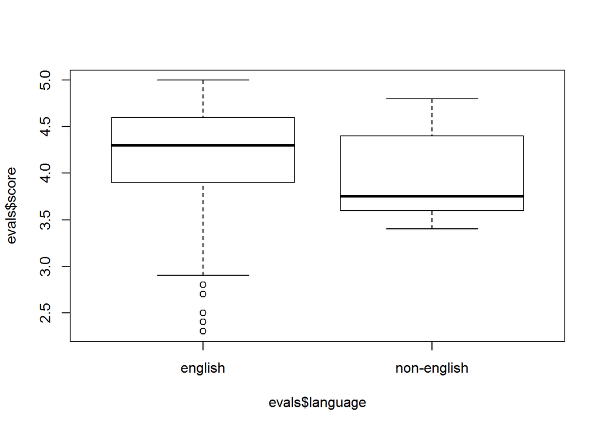

```r
plot(evals$score ~ evals$language)
```

- It appears that language has the high impact on score .

**Ex 13 ..**  
**Interpret the coefficient associated with the ethnicity variable.**

- As mentioned above, ethnicity does not appear to be significant in predicting the scores of professors. The p-value here is 0.12, which is above our 5% threshold.

**Ex 14 ..**  
**Drop the variable with the highest p-value and re-fit the model. Did the coefficients and significance of the other explanatory variables change? (One of the things that makes multiple regression interesting is that coefficient estimates depend on the other variables that are included in the model.) If not, what does this say about whether or not the dropped variable was collinear with the other explanatory variables?**

```r
m_full_less_profs <- lm(score ~ rank + ethnicity + gender + language + age + cls_perc_eval
             + cls_students + cls_level + cls_credits + bty_avg
             + pic_outfit + pic_color, data = evals)
summary(m_full_less_profs)
```

```
##
## Call:
## lm(formula = score ~ rank + ethnicity + gender + language + age +
##     cls_perc_eval + cls_students + cls_level + cls_credits +
##     bty_avg + pic_outfit + pic_color, data = evals)
##
## Residuals:
##     Min      1Q  Median      3Q     Max
## -1.7836 -0.3257  0.0859  0.3513  0.9551
##
## Coefficients:
##                         Estimate Std. Error t value Pr(>|t|)
## (Intercept)            4.0872523  0.2888562  14.150  < 2e-16 ***
## ranktenure track      -0.1476746  0.0819824  -1.801 0.072327 .
## ranktenured           -0.0973829  0.0662614  -1.470 0.142349
## ethnicitynot minority  0.1274458  0.0772887   1.649 0.099856 .
## gendermale             0.2101231  0.0516873   4.065 5.66e-05 ***
## languagenon-english   -0.2282894  0.1111305  -2.054 0.040530 *
## age                   -0.0089992  0.0031326  -2.873 0.004262 **
## cls_perc_eval          0.0052888  0.0015317   3.453 0.000607 ***
## cls_students           0.0004687  0.0003737   1.254 0.210384
## cls_levelupper         0.0606374  0.0575010   1.055 0.292200
## cls_creditsone credit  0.5061196  0.1149163   4.404 1.33e-05 ***
## bty_avg                0.0398629  0.0174780   2.281 0.023032 *
## pic_outfitnot formal  -0.1083227  0.0721711  -1.501 0.134080
## pic_colorcolor        -0.2190527  0.0711469  -3.079 0.002205 **
## ---
## Signif. codes:  0 '***' 0.001 '**' 0.01 '*' 0.05 '.' 0.1 ' ' 1
##
## Residual standard error: 0.4974 on 449 degrees of freedom
## Multiple R-squared:  0.187,  Adjusted R-squared:  0.1634
## F-statistic: 7.943 on 13 and 449 DF,  p-value: 2.336e-14
```

- Our R squared adjusted changed slightly, but more importantly, our p-values seemed to have changed. It seems like now we have no p-value above 0.3, while before we had some up to 0.7.

**Ex 15 ..**  
**Using backward-selection and p-value as the selection criterion, determine the best model. You do not need to show all steps in your answer, just the output for the final model. Also, write out the linear model for predicting score based on the final model you settle on.**

```r
# Looking at the previous question, we can see that the next highest p value is: cls_level.
m_backwards <- lm(formula = score ~ rank + ethnicity + gender + language + age +
    cls_perc_eval + cls_students + cls_credits +
    bty_avg + pic_outfit + pic_color, data = evals)
summary(m_backwards)
```

```
##
## Call:
## lm(formula = score ~ rank + ethnicity + gender + language + age +
##     cls_perc_eval + cls_students + cls_credits + bty_avg + pic_outfit +
##     pic_color, data = evals)
##
## Residuals:
##     Min      1Q  Median      3Q     Max
## -1.7761 -0.3187  0.0875  0.3547  0.9367
##
## Coefficients:
##                         Estimate Std. Error t value Pr(>|t|)
## (Intercept)            4.0856255  0.2888881  14.143  < 2e-16 ***
## ranktenure track      -0.1420696  0.0818201  -1.736 0.083184 .
## ranktenured           -0.0895940  0.0658566  -1.360 0.174372
## ethnicitynot minority  0.1424342  0.0759800   1.875 0.061491 .
## gendermale             0.2037722  0.0513416   3.969 8.40e-05 ***
## languagenon-english   -0.2093185  0.1096785  -1.908 0.056966 .
## age                   -0.0087287  0.0031224  -2.795 0.005404 **
## cls_perc_eval          0.0053545  0.0015306   3.498 0.000515 ***
## cls_students           0.0003573  0.0003585   0.997 0.319451
## cls_creditsone credit  0.4733728  0.1106549   4.278 2.31e-05 ***
## bty_avg                0.0410340  0.0174449   2.352 0.019092 *
## pic_outfitnot formal  -0.1172152  0.0716857  -1.635 0.102722
## pic_colorcolor        -0.1973196  0.0681052  -2.897 0.003948 **
## ---
## Signif. codes:  0 '***' 0.001 '**' 0.01 '*' 0.05 '.' 0.1 ' ' 1
##
## Residual standard error: 0.4975 on 450 degrees of freedom
## Multiple R-squared:  0.185,  Adjusted R-squared:  0.1632
## F-statistic:  8.51 on 12 and 450 DF,  p-value: 1.275e-14
```

- The model created above actually seems to be best. I tried to remove the next highest p-value, cls_level, but the R-squared fell slightly, and a few of the p-values were higher than in the previous model.

**Ex 16 ..**  
**Verify that the conditions for this model are reasonable using diagnostic plots.**

```r
summary(m_full_less_profs)
```

```
##
## Call:
## lm(formula = score ~ rank + ethnicity + gender + language + age +
##     cls_perc_eval + cls_students + cls_level + cls_credits +
##     bty_avg + pic_outfit + pic_color, data = evals)
##
## Residuals:
##     Min      1Q  Median      3Q     Max
## -1.7836 -0.3257  0.0859  0.3513  0.9551
##
## Coefficients:
##                         Estimate Std. Error t value Pr(>|t|)
## (Intercept)            4.0872523  0.2888562  14.150  < 2e-16 ***
## ranktenure track      -0.1476746  0.0819824  -1.801 0.072327 .
## ranktenured           -0.0973829  0.0662614  -1.470 0.142349
## ethnicitynot minority  0.1274458  0.0772887   1.649 0.099856 .
## gendermale             0.2101231  0.0516873   4.065 5.66e-05 ***
## languagenon-english   -0.2282894  0.1111305  -2.054 0.040530 *
## age                   -0.0089992  0.0031326  -2.873 0.004262 **
## cls_perc_eval          0.0052888  0.0015317   3.453 0.000607 ***
## cls_students           0.0004687  0.0003737   1.254 0.210384
## cls_levelupper         0.0606374  0.0575010   1.055 0.292200
## cls_creditsone credit  0.5061196  0.1149163   4.404 1.33e-05 ***
## bty_avg                0.0398629  0.0174780   2.281 0.023032 *
## pic_outfitnot formal  -0.1083227  0.0721711  -1.501 0.134080
## pic_colorcolor        -0.2190527  0.0711469  -3.079 0.002205 **
## ---
## Signif. codes:  0 '***' 0.001 '**' 0.01 '*' 0.05 '.' 0.1 ' ' 1
##
## Residual standard error: 0.4974 on 449 degrees of freedom
## Multiple R-squared:  0.187,  Adjusted R-squared:  0.1634
## F-statistic: 7.943 on 13 and 449 DF,  p-value: 2.336e-14
```

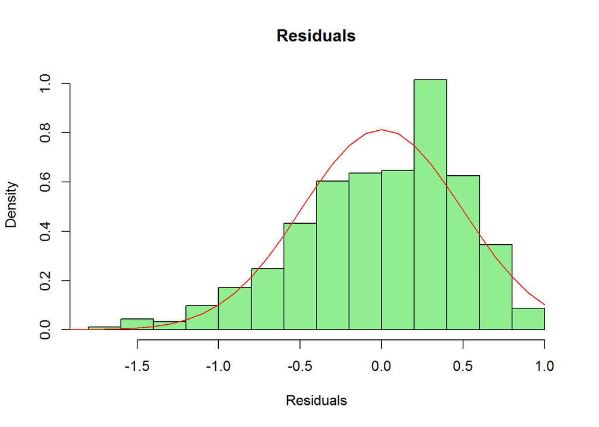

```r
hist(m_full_less_profs$residuals, main = "Residuals", xlab = "Residuals", col = "lightgreen", prob = TRUE)
x1 <- seq(-2,1, by=.1)
y1 <- dnorm(x = x1, mean = mean(m_full_less_profs$residuals), sd = sd(m_full_less_profs$residuals))
lines(x = x1, y = y1, col = "red")
```

```r
summary(m_full_less_profs$residuals)
```

```
##    Min. 1st Qu.  Median    Mean 3rd Qu.    Max.
## -1.7840 -0.3257  0.0859  0.0000  0.3513  0.9551
```

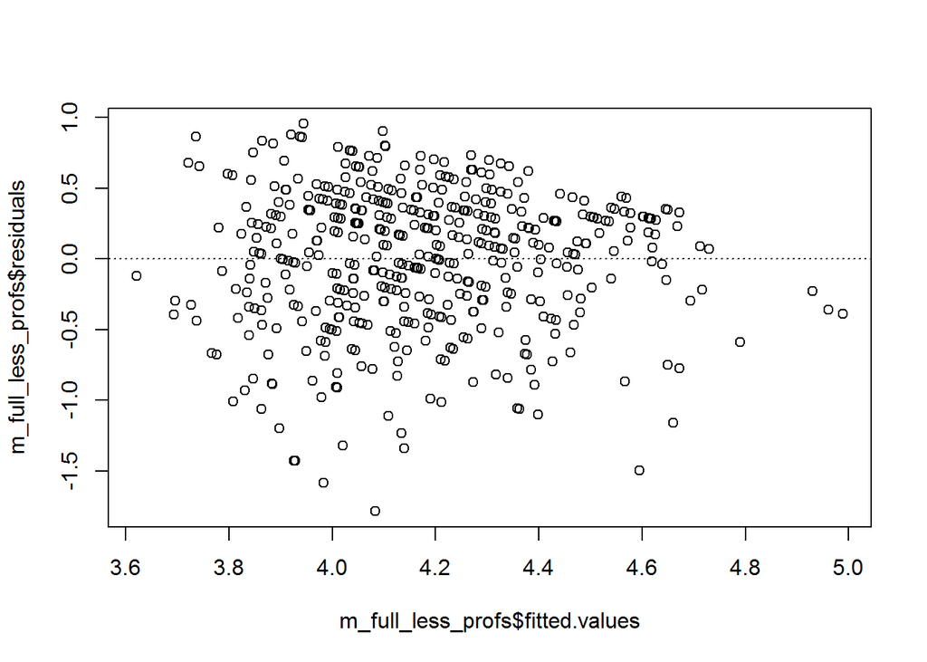

```r
plot(m_full_less_profs$residuals ~ m_full_less_profs$fitted.values)
abline(h = 0, lty = 3)
```

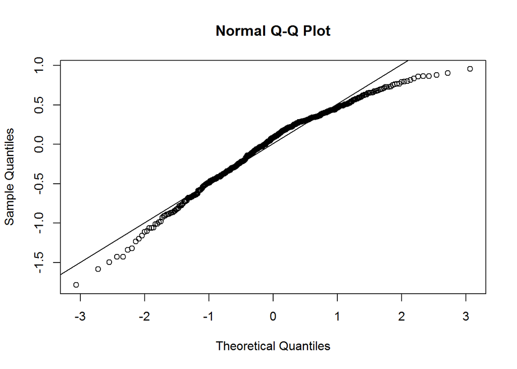

```r
qqnorm(m_full_less_profs$residuals)
qqline(m_full_less_profs$residuals)
```

- It seems like the residuals are as normal as in the models we were studying before. If we wanted to truly check all diagnostic plots, we’d want to check the scatter plots to make sure our data looks fairly linear

**Ex 17 ..**  
**The original paper describes how these data were gathered by taking a sample of professors from the University of Texas at Austin and including all courses that they have taught. Considering that each row represents a course, could this new information have an impact on any of the conditions of linear regression?**

- I’d be interested to see if they double count professors in classes. In order to properly model this, they should link the scores given to professors in different classes, and average them (making sure to account for the increased sample)

**Ex 18 ..**  
**Based on your final model, describe the characteristics of a professor and course at University of Texas at Austin that would be associated with a high evaluation score.**

- Based on the final model, the qualities being associated with a high evaluation score are being of teaching rank, non-minority, male, speaking english, younger, and teaching one credit classes.

**Ex 19 ..**  
**Would you be comfortable generalizing your conclusions to apply to professors generally (at any university)? Why or why not?**

- No because this is observational data. Observational data cannot be used to dictate causation. And in addition, this sample size was taken from one university, which is by no means sufficient as generalizable.